# knn_water

KAGGLE LINK : kaggle competitions download -c water-quality-prediction-rk

**PROBLEM STATEMENT:**

A growing number of factors, including pollution, population expansion, and climate change, are putting the world's water resources in danger. How to obtain enough water to satisfy human demands while also conserving the integrity of aquatic ecosystems is a recurring concern as the world's population rises. The Pacific Institute works on global water resource issues in partnership with stakeholders to make sure that people and nature have access to the water they require to survive today and in the future. Our aim is to train a machine learning model based on the water quality data provided to you in the training file and further predict the quality estimation result for the test dataset.

**COLUMNS:**

id: The unique ID for each row.

categoryA - categoryF: 6 category columns with suffix A to F.

featureA - featureI: 9 feature columns with suffix A to I.

compositionA - compositionJ: 10 composition columns with suffix A to J.

unit: The unit of measurement for the result values.

result: The measure for water quality (target variable).

```python
# importing the neccessary libraries
import os
import pandas as pd
import numpy as np
import seaborn as sns
import matplotlib.pyplot as plt
from scipy import stats
from scipy.stats import skew,norm
```

```python
# reading the train data
train=pd.read_csv("/content/train.csv")
train.head()
```

|  | id | categoryA | categoryB | categoryC | categoryD | categoryE | categoryF | featureA | featureB | featureC | ... | compositionC | compositionD | compositionE | compositionF | compositionG | compositionH | compositionI | compositionJ | unit | result |
| --- | --- | --- | --- | --- | --- | --- | --- | --- | --- | --- | --- | --- | --- | --- | --- | --- | --- | --- | --- | --- | --- |
| 0 | a563699ca2a601c6ac64aa29986a00a90fb42b48741695... | catA_1 | catB_0 | catC_718 | catD_0 | catE_0 | catF_0 | 75808.375 | 4.457840 | 0.005718 | ... | 26.0 | 0.0 | 32.0 | 3.0 | 0.0 | 9.0 | 22.26 | 20.0 | unit_6 | 0.000458 |
| 1 | 91ab3eb3bcf6c8c1c5fe2da9ba671aa5a48c7369d9a50f... | catA_1 | catB_0 | catC_1309 | catD_0 | catE_0 | catF_0 | 75808.375 | 4.457840 | 0.005718 | ... | 26.0 | 0.0 | 32.0 | 3.0 | 0.0 | 9.0 | 22.26 | 20.0 | unit_6 | 0.000335 |
| 2 | 7128c51c554735d6c81862684ad6005ae12d2edbcd4644... | catA_15 | catB_0 | catC_1309 | catD_0 | catE_0 | catF_0 | 75808.375 | 4.457840 | 0.005718 | ... | 26.0 | 0.0 | 32.0 | 3.0 | 0.0 | 9.0 | 22.26 | 20.0 | unit_4 | 0.054072 |
| 3 | c8144b52e4f63014de0a0d8e1c629bf0b05cb2696cfc23... | catA_0 | catB_0 | catC_935 | catD_0 | catE_0 | catF_0 | 75808.375 | 4.457840 | 0.005718 | ... | 26.0 | 0.0 | 32.0 | 3.0 | 0.0 | 9.0 | 22.26 | 20.0 | unit_5 | 0.061143 |
| 4 | 88d15a5b2df6692f23d105ff1ae82ae026be00c9271eef... | catA_22 | catB_0 | catC_1325 | catD_0 | catE_2 | catF_0 | -40055.250 | 4.363288 | 0.729194 | ... | 14.0 | 0.0 | 49.0 | 3.0 | 2.0 | 9.0 | 16.84 | 15.0 | unit_15 | 0.015439 |

5 rows × 28 columns

```python
train.shape
```

```
(13000, 28)
```

```python
# reading the test data
test=pd.read_csv("/content/test.csv")
test.head()
```

|  | id | categoryA | categoryB | categoryC | categoryD | categoryE | categoryF | featureA | featureB | featureC | ... | compositionB | compositionC | compositionD | compositionE | compositionF | compositionG | compositionH | compositionI | compositionJ | unit |
| --- | --- | --- | --- | --- | --- | --- | --- | --- | --- | --- | --- | --- | --- | --- | --- | --- | --- | --- | --- | --- | --- |
| 0 | 939edadbc8e0cddf21c8c5710c4f2f909abd36c196aee8... | catA_6 | catB_0 | catC_55 | catD_0 | catE_1 | catF_0 | 325435.125 | 1.728675 | 0.032407 | ... | 2.2 | 28.2 | 2.7 | 16.7 | 3.5 | 7.6 | 20.2 | 27.25 | 18.9 | unit_7 |
| 1 | fcfed000585350fdc6a982bd1146cd8cdd71d989a2fb01... | catA_6 | catB_0 | catC_1638 | catD_0 | catE_0 | catF_0 | 75808.375 | 4.457840 | 0.005718 | ... | 10.0 | 26.0 | 0.0 | 32.0 | 3.0 | 0.0 | 9.0 | 22.26 | 20.0 | unit_7 |
| 2 | 917b412b73b7c1c83f779d2f350acda4d2b14804579e79... | catA_17 | catB_0 | catC_1400 | catD_0 | catE_16 | catF_0 | -19688.875 | 25.982190 | 0.000000 | ... | 21.4 | 9.7 | 0.0 | 46.7 | 2.6 | 2.4 | 7.7 | 21.23 | 6.1 | unit_12 |
| 3 | 012d646dbd712fd4b752aa8761dc18aaf28643c262f859... | catA_5 | catB_0 | catC_204 | catD_0 | catE_0 | catF_0 | 75808.375 | 4.457840 | 0.005718 | ... | 10.0 | 26.0 | 0.0 | 32.0 | 3.0 | 0.0 | 9.0 | 22.26 | 20.0 | unit_0 |
| 4 | 77c69c2a873444dfef22131bada7d9504ad731ca8df55d... | catA_5 | catB_0 | catC_1282 | catD_0 | catE_2 | catF_0 | -40055.250 | 4.363288 | 0.729194 | ... | 8.0 | 14.0 | 0.0 | 49.0 | 3.0 | 2.0 | 9.0 | 16.84 | 15.0 | unit_0 |

5 rows × 27 columns

```python
print(train.columns,train.shape)
print('\n')
print(test.columns,test.shape)
```

```
Index(['id', 'categoryA', 'categoryB', 'categoryC', 'categoryD', 'categoryE',
       'categoryF', 'featureA', 'featureB', 'featureC', 'featureD', 'featureE',
       'featureF', 'featureG', 'featureH', 'featureI', 'compositionA',
       'compositionB', 'compositionC', 'compositionD', 'compositionE',
       'compositionF', 'compositionG', 'compositionH', 'compositionI',
       'compositionJ', 'unit', 'result'],
      dtype='object') (13000, 28)


Index(['id', 'categoryA', 'categoryB', 'categoryC', 'categoryD', 'categoryE',
       'categoryF', 'featureA', 'featureB', 'featureC', 'featureD', 'featureE',
       'featureF', 'featureG', 'featureH', 'featureI', 'compositionA',
       'compositionB', 'compositionC', 'compositionD', 'compositionE',
       'compositionF', 'compositionG', 'compositionH', 'compositionI',
       'compositionJ', 'unit'],
      dtype='object') (7000, 27)
```

```python
# saving the ID column
train_ID = train['id']
test_ID = test['id']

# dropping the ID column as it is unnecessary for the prediction process
train.drop("id",axis=1,inplace=True)
test.drop("id",axis=1,inplace=True)
```

```python
print(train.shape)
print(test.shape)
```

```
(13000, 27)
(7000, 26)
```

```python
train.nunique(axis=0)
```

```
categoryA         167
categoryB           2
categoryC        2212
categoryD           3
categoryE          25
categoryF           3
featureA           23
featureB           23
featureC           19
featureD           23
featureE           23
featureF           23
featureG           23
featureH           11
featureI           23
compositionA        5
compositionB       21
compositionC       23
compositionD        9
compositionE       22
compositionF       20
compositionG       15
compositionH       22
compositionI       23
compositionJ       21
unit               19
result          10329
dtype: int64
```

```python
train.info()
```

```
<class 'pandas.core.frame.DataFrame'>
RangeIndex: 13000 entries, 0 to 12999
Data columns (total 27 columns):
 #   Column        Non-Null Count  Dtype
---  ------        --------------  -----
 0   categoryA     13000 non-null  object
 1   categoryB     13000 non-null  object
 2   categoryC     13000 non-null  object
 3   categoryD     13000 non-null  object
 4   categoryE     13000 non-null  object
 5   categoryF     13000 non-null  object
 6   featureA      12936 non-null  float64
 7   featureB      12936 non-null  float64
 8   featureC      12936 non-null  float64
 9   featureD      12936 non-null  float64
```

[output cut: 19 more lines]

```python
train.dtypes.value_counts()
```

```
float64    19
object      7
int64       1
dtype: int64
```

```python
# coverting the column from object to category
train = train.astype({'categoryA':'category', 'categoryB': 'category','categoryC':'category','categoryD':'category','categoryE':'category','categoryF':'category','unit':'category'})
train.dtypes
```

```
categoryA       category
categoryB       category
categoryC       category
categoryD       category
categoryE       category
categoryF       category
featureA         float64
featureB         float64
featureC         float64
featureD         float64
featureE         float64
featureF           int64
featureG         float64
featureH         float64
featureI         float64
compositionA     float64
compositionB     float64
compositionC     float64
compositionD     float64
compositionE     float64
compositionF     float64
compositionG     float64
compositionH     float64
compositionI     float64
compositionJ     float64
unit            category
result           float64
dtype: object
```

```python
train.describe().T
```

|  | count | mean | std | min | 25% | 50% | 75% | max |
| --- | --- | --- | --- | --- | --- | --- | --- | --- |
| featureA | 12936.0 | 1.165592e+05 | 1.465020e+05 | -8.374975e+04 | 5.674475e+04 | 7.580838e+04 | 7.580838e+04 | 5.822110e+05 |
| featureB | 12936.0 | 4.526278e+00 | 3.180817e+00 | 1.064468e+00 | 4.363288e+00 | 4.457840e+00 | 4.457840e+00 | 2.598219e+01 |
| featureC | 12936.0 | 1.329723e-01 | 2.641483e-01 | 0.000000e+00 | 5.717646e-03 | 5.717646e-03 | 3.240702e-02 | 7.291935e-01 |
| featureD | 12936.0 | 1.503411e+02 | 7.509367e+01 | 1.814855e+01 | 1.222994e+02 | 1.222994e+02 | 1.379766e+02 | 5.114759e+02 |
| featureE | 12936.0 | 2.644618e+01 | 6.665619e+00 | 3.875411e+00 | 2.462550e+01 | 3.083191e+01 | 3.083191e+01 | 3.876723e+01 |
| featureF | 13000.0 | 2.175385e-01 | 2.380893e+00 | 0.000000e+00 | 0.000000e+00 | 0.000000e+00 | 0.000000e+00 | 1.000000e+02 |
| featureG | 12936.0 | 2.335366e+12 | 8.937307e+11 | 2.887150e+10 | 1.464510e+12 | 2.806040e+12 | 2.806040e+12 | 3.781700e+12 |
| featureH | 12936.0 | 1.504719e+01 | 3.200037e+01 | 0.000000e+00 | 0.000000e+00 | 0.000000e+00 | 0.000000e+00 | 8.715892e+01 |
| featureI | 12936.0 | 5.020210e+07 | 2.412360e+07 | 5.300380e+05 | 2.586796e+07 | 5.094169e+07 | 7.117635e+07 | 7.117635e+07 |
| compositionA | 12936.0 | 1.649227e-01 | 7.432285e-01 | 0.000000e+00 | 0.000000e+00 | 0.000000e+00 | 0.000000e+00 | 4.000000e+00 |
| compositionB | 12936.0 | 7.708228e+00 | 3.208687e+00 | 2.200000e+00 | 5.830000e+00 | 1.000000e+01 | 1.000000e+01 | 2.140000e+01 |
| compositionC | 12936.0 | 2.362752e+01 | 6.433507e+00 | 0.000000e+00 | 1.770000e+01 | 2.600000e+01 | 2.600000e+01 | 4.405000e+01 |
| compositionD | 12936.0 | 1.296887e+00 | 3.724154e+00 | 0.000000e+00 | 0.000000e+00 | 0.000000e+00 | 1.940000e+00 | 3.046000e+01 |
| compositionE | 12936.0 | 3.203812e+01 | 1.109817e+01 | 1.278000e+01 | 3.000000e+01 | 3.200000e+01 | 3.200000e+01 | 6.230000e+01 |
| compositionF | 12936.0 | 3.178698e+00 | 1.098585e+00 | 1.380000e+00 | 3.000000e+00 | 3.000000e+00 | 3.000000e+00 | 9.200000e+00 |
| compositionG | 12936.0 | 2.024316e+00 | 2.964965e+00 | 0.000000e+00 | 0.000000e+00 | 0.000000e+00 | 2.000000e+00 | 7.900000e+00 |
| compositionH | 12936.0 | 1.121470e+01 | 4.860118e+00 | 1.450000e+00 | 9.000000e+00 | 9.000000e+00 | 1.233000e+01 | 2.020000e+01 |
| compositionI | 12936.0 | 2.338609e+01 | 5.937944e+00 | 7.600000e-01 | 2.226000e+01 | 2.226000e+01 | 2.725000e+01 | 4.783000e+01 |
| compositionJ | 12936.0 | 1.894259e+01 | 4.096265e+00 | 6.100000e+00 | 1.890000e+01 | 2.000000e+01 | 2.000000e+01 | 3.783000e+01 |
| result | 13000.0 | 1.442228e-01 | 2.240620e-01 | 0.000000e+00 | 3.875360e-03 | 2.790881e-02 | 1.686778e-01 | 1.000000e+00 |

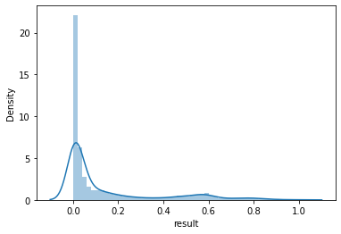

```
skewness: 1.671125
kurtosis: 1.590801
```

```python
# Skewness is a measure of symmetry, or more precisely, the lack of symmetry.
# A distribution, or data set, is symmetric if it looks the same to the left and right of the center point.
# Kurtosis is a measure of whether the data are heavy-tailed or light-tailed relative to a normal distribution.

import warnings
warnings.filterwarnings("ignore")

#kernel density plot
sns.distplot(train.result)
plt.show()
print('\n')
print("skewness: %f" % train['result'].skew())
print("kurtosis: %f" % train ['result'].kurt())
```

Here, the data is positively (right) skewed.

```python
train.skew()
```

```
featureA         1.306407
featureB         3.797456
featureC         1.795937
featureD         1.003517
featureE        -0.889903
featureF        31.217804
featureG        -1.312239
featureH         1.784785
featureI        -0.646499
compositionA     4.607279
compositionB    -0.802405
compositionC    -0.552444
compositionD     4.783189
compositionE     0.422508
compositionF     3.682130
compositionG     1.205124
compositionH     0.901407
compositionI     1.705621
compositionJ     1.677662
result           1.671125
dtype: float64
```

```python
# replacing the value to make it easy for us
train = train.applymap(lambda x: x.replace('catA_', '') if isinstance(x, str) else x)
train = train.applymap(lambda x: x.replace('catB_', '') if isinstance(x, str) else x)
train = train.applymap(lambda x: x.replace('catC_', '') if isinstance(x, str) else x)
train = train.applymap(lambda x: x.replace('catD_', '') if isinstance(x, str) else x)
train = train.applymap(lambda x: x.replace('catE_', '') if isinstance(x, str) else x)
train = train.applymap(lambda x: x.replace('catF_', '') if isinstance(x, str) else x)
train = train.applymap(lambda x: x.replace('unit_', '') if isinstance(x, str) else x)

# display the updated DataFrame
train.head()
```

|  | categoryA | categoryB | categoryC | categoryD | categoryE | categoryF | featureA | featureB | featureC | featureD | ... | compositionC | compositionD | compositionE | compositionF | compositionG | compositionH | compositionI | compositionJ | unit | result |
| --- | --- | --- | --- | --- | --- | --- | --- | --- | --- | --- | --- | --- | --- | --- | --- | --- | --- | --- | --- | --- | --- |
| 0 | 1 | 0 | 718 | 0 | 0 | 0 | 75808.375 | 4.457840 | 0.005718 | 122.299437 | ... | 26.0 | 0.0 | 32.0 | 3.0 | 0.0 | 9.0 | 22.26 | 20.0 | 6 | 0.000458 |
| 1 | 1 | 0 | 1309 | 0 | 0 | 0 | 75808.375 | 4.457840 | 0.005718 | 122.299437 | ... | 26.0 | 0.0 | 32.0 | 3.0 | 0.0 | 9.0 | 22.26 | 20.0 | 6 | 0.000335 |
| 2 | 15 | 0 | 1309 | 0 | 0 | 0 | 75808.375 | 4.457840 | 0.005718 | 122.299437 | ... | 26.0 | 0.0 | 32.0 | 3.0 | 0.0 | 9.0 | 22.26 | 20.0 | 4 | 0.054072 |
| 3 | 0 | 0 | 935 | 0 | 0 | 0 | 75808.375 | 4.457840 | 0.005718 | 122.299437 | ... | 26.0 | 0.0 | 32.0 | 3.0 | 0.0 | 9.0 | 22.26 | 20.0 | 5 | 0.061143 |
| 4 | 22 | 0 | 1325 | 0 | 2 | 0 | -40055.250 | 4.363288 | 0.729194 | 93.677197 | ... | 14.0 | 0.0 | 49.0 | 3.0 | 2.0 | 9.0 | 16.84 | 15.0 | 15 | 0.015439 |

5 rows × 27 columns

```python
#descriptuve statistics summary of target variable
train['result'].describe()
```

```
count    13000.000000
mean         0.144223
std          0.224062
min          0.000000
25%          0.003875
50%          0.027909
75%          0.168678
max          1.000000
Name: result, dtype: float64
```

```python
train.isnull().sum()
```

```
categoryA        0
categoryB        0
categoryC        0
categoryD        0
categoryE        0
categoryF        0
featureA        64
featureB        64
featureC        64
featureD        64
featureE        64
featureF         0
featureG        64
featureH        64
featureI        64
compositionA    64
compositionB    64
compositionC    64
compositionD    64
compositionE    64
compositionF    64
compositionG    64
compositionH    64
compositionI    64
compositionJ    64
unit             0
result           0
dtype: int64
```

```python
# Fill null values using median
median = train.median()
train.fillna(median, inplace=True)
```

```python
train.isnull().sum().sum()
```

```
0
```

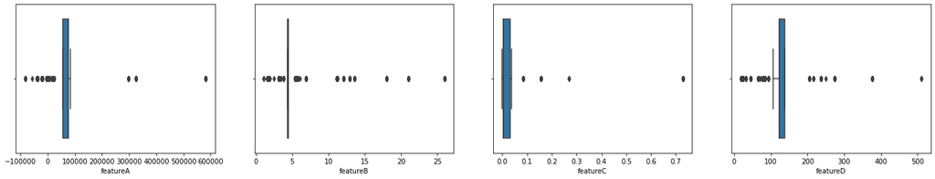

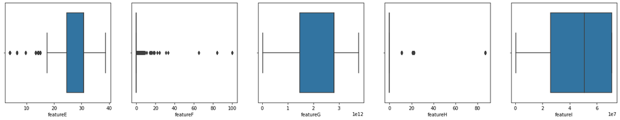

```python
#plotting boxplot to know the outliers of feature data
import warnings
warnings.filterwarnings('ignore')
plt.figure(figsize = (24,4))
plt.subplot(1,4,1)
sns.boxplot(train['featureA'])
plt.subplot(1,4,2)
sns.boxplot(train['featureB'])
plt.subplot(1,4,3)
sns.boxplot(train['featureC'])
plt.subplot(1,4,4)
sns.boxplot(train['featureD'])
plt.show()
plt.figure(figsize = (24,4))
plt.subplot(1,5,1)
sns.boxplot(train['featureE'])
plt.subplot(1,5,2)
sns.boxplot(train['featureF'])
plt.subplot(1,5,3)
sns.boxplot(train['featureG'])
plt.subplot(1,5,4)
sns.boxplot(train['featureH'])
plt.subplot(1,5,5)
sns.boxplot(train['featureI'])
plt.show()
```

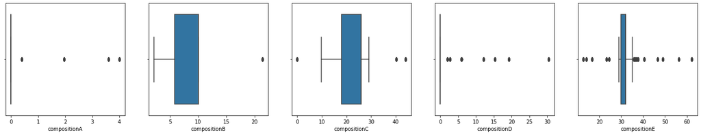

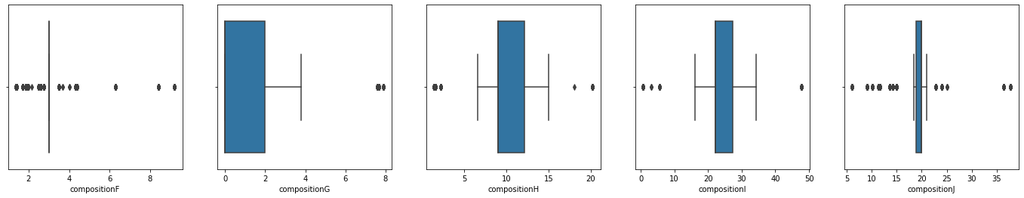

```python
#plotting boxplot to know the outliers of Composition data
import warnings
warnings.filterwarnings('ignore')
plt.figure(figsize = (24,4))
plt.subplot(1,5,1)
sns.boxplot(train['compositionA'])
plt.subplot(1,5,2)
sns.boxplot(train['compositionB'])
plt.subplot(1,5,3)
sns.boxplot(train['compositionC'])
plt.subplot(1,5,4)
sns.boxplot(train['compositionD'])
plt.subplot(1,5,5)
sns.boxplot(train['compositionE'])
plt.show()
plt.figure(figsize = (24,4))
plt.subplot(1,5,1)
sns.boxplot(train['compositionF'])
plt.subplot(1,5,2)
sns.boxplot(train['compositionG'])
plt.subplot(1,5,3)
sns.boxplot(train['compositionH'])
plt.subplot(1,5,4)
sns.boxplot(train['compositionI'])
plt.subplot(1,5,5)
sns.boxplot(train['compositionJ'])
plt.show()
```

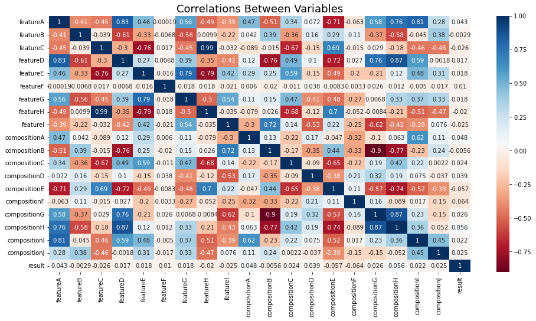

```python
#correlation matrix
plt.figure(figsize=(16,8))
sns.heatmap(train.corr(),annot=True, cmap="RdBu")
plt.title("Correlations Between Variables", size=18)
plt.show() #'RdBu' says take red to blue and having white in the middle , Red is negatively correlated and Blue is positively correlated
```

```python
# dropping few columns that are unccessary after obeserving correlation matrix
#fD,cI,fH,fE,fI,cG
train = train.drop(['featureD','featureG','featureH','featureI','compositionG','compositionI'],axis=1)
```

```python
# Checking and removing any duplicates from the data
train[train.duplicated()]
train.drop_duplicates(inplace=True)
train
```

|  | categoryA | categoryB | categoryC | categoryD | categoryE | categoryF | featureA | featureB | featureC | featureE | ... | compositionA | compositionB | compositionC | compositionD | compositionE | compositionF | compositionH | compositionJ | unit | result |
| --- | --- | --- | --- | --- | --- | --- | --- | --- | --- | --- | --- | --- | --- | --- | --- | --- | --- | --- | --- | --- | --- |
| 0 | 1 | 0 | 718 | 0 | 0 | 0 | 75808.375 | 4.457840 | 0.005718 | 30.831906 | ... | 0.0 | 10.00 | 26.00 | 0.0 | 32.00 | 3.0 | 9.00 | 20.00 | 6 | 0.000458 |
| 1 | 1 | 0 | 1309 | 0 | 0 | 0 | 75808.375 | 4.457840 | 0.005718 | 30.831906 | ... | 0.0 | 10.00 | 26.00 | 0.0 | 32.00 | 3.0 | 9.00 | 20.00 | 6 | 0.000335 |
| 2 | 15 | 0 | 1309 | 0 | 0 | 0 | 75808.375 | 4.457840 | 0.005718 | 30.831906 | ... | 0.0 | 10.00 | 26.00 | 0.0 | 32.00 | 3.0 | 9.00 | 20.00 | 4 | 0.054072 |
| 3 | 0 | 0 | 935 | 0 | 0 | 0 | 75808.375 | 4.457840 | 0.005718 | 30.831906 | ... | 0.0 | 10.00 | 26.00 | 0.0 | 32.00 | 3.0 | 9.00 | 20.00 | 5 | 0.061143 |
| 4 | 22 | 0 | 1325 | 0 | 2 | 0 | -40055.250 | 4.363288 | 0.729194 | 15.047884 | ... | 0.0 | 8.00 | 14.00 | 0.0 | 49.00 | 3.0 | 9.00 | 15.00 | 15 | 0.015439 |
| ... | ... | ... | ... | ... | ... | ... | ... | ... | ... | ... | ... | ... | ... | ... | ... | ... | ... | ... | ... | ... | ... |
| 12995 | 3 | 0 | 639 | 0 | 0 | 0 | 75808.375 | 4.457840 | 0.005718 | 30.831906 | ... | 0.0 | 10.00 | 26.00 | 0.0 | 32.00 | 3.0 | 9.00 | 20.00 | 1 | 0.008260 |
| 12996 | 8 | 0 | 445 | 0 | 0 | 0 | 75808.375 | 4.457840 | 0.005718 | 30.831906 | ... | 0.0 | 10.00 | 26.00 | 0.0 | 32.00 | 3.0 | 9.00 | 20.00 | 9 | 0.002395 |
| 12997 | 25 | 0 | 445 | 0 | 0 | 1 | 75808.375 | 4.457840 | 0.005718 | 30.831906 | ... | 0.0 | 10.00 | 26.00 | 0.0 | 32.00 | 3.0 | 9.00 | 20.00 | 12 | 0.150982 |
| 12998 | 7 | 0 | 2322 | 0 | 5 | 0 | 18927.000 | 21.007457 | 0.000387 | 14.177182 | ... | 0.0 | 9.24 | 13.13 | 0.0 | 35.88 | 1.7 | 1.45 | 37.83 | 8 | 0.488908 |
| 12999 | 9 | 0 | 2322 | 0 | 5 | 0 | 18927.000 | 21.007457 | 0.000387 | 14.177182 | ... | 0.0 | 9.24 | 13.13 | 0.0 | 35.88 | 1.7 | 1.45 | 37.83 | 10 | 0.232833 |

12941 rows × 21 columns

```python
# retriving num cols after dropping so remainning cols will appear
train_num=train._get_numeric_data()
train_num.head()
```

|  | featureA | featureB | featureC | featureE | featureF | compositionA | compositionB | compositionC | compositionD | compositionE | compositionF | compositionH | compositionJ | result |
| --- | --- | --- | --- | --- | --- | --- | --- | --- | --- | --- | --- | --- | --- | --- |
| 0 | 75808.375 | 4.457840 | 0.005718 | 30.831906 | 0 | 0.0 | 10.0 | 26.0 | 0.0 | 32.0 | 3.0 | 9.0 | 20.0 | 0.000458 |
| 1 | 75808.375 | 4.457840 | 0.005718 | 30.831906 | 0 | 0.0 | 10.0 | 26.0 | 0.0 | 32.0 | 3.0 | 9.0 | 20.0 | 0.000335 |
| 2 | 75808.375 | 4.457840 | 0.005718 | 30.831906 | 0 | 0.0 | 10.0 | 26.0 | 0.0 | 32.0 | 3.0 | 9.0 | 20.0 | 0.054072 |
| 3 | 75808.375 | 4.457840 | 0.005718 | 30.831906 | 2 | 0.0 | 10.0 | 26.0 | 0.0 | 32.0 | 3.0 | 9.0 | 20.0 | 0.061143 |
| 4 | -40055.250 | 4.363288 | 0.729194 | 15.047884 | 4 | 0.0 | 8.0 | 14.0 | 0.0 | 49.0 | 3.0 | 9.0 | 15.0 | 0.015439 |

```python
train_cat = train.select_dtypes(include = object)
train_cat.head()
```

|  | categoryA | categoryB | categoryC | categoryD | categoryE | categoryF | unit |
| --- | --- | --- | --- | --- | --- | --- | --- |
| 0 | 1 | 0 | 718 | 0 | 0 | 0 | 6 |
| 1 | 1 | 0 | 1309 | 0 | 0 | 0 | 6 |
| 2 | 15 | 0 | 1309 | 0 | 0 | 0 | 4 |
| 3 | 0 | 0 | 935 | 0 | 0 | 0 | 5 |
| 4 | 22 | 0 | 1325 | 0 | 2 | 0 | 15 |

```python
train_cat.isnull().sum()
```

```
categoryA    0
categoryB    0
categoryC    0
categoryD    0
categoryE    0
categoryF    0
unit         0
dtype: int64
```

```python
train_cat.nunique(axis=0)
```

```
categoryA     167
categoryB       2
categoryC    2212
categoryD       3
categoryE      25
categoryF       3
unit           19
dtype: int64
```

```python
# dummification for categorical columns
g_d=pd.get_dummies(train_cat)
```

```python
g_d.head()
```

|  | categoryA_0 | categoryA_1 | categoryA_10 | categoryA_100 | categoryA_101 | categoryA_102 | categoryA_103 | categoryA_104 | categoryA_105 | categoryA_106 | ... | unit_17 | unit_18 | unit_2 | unit_3 | unit_4 | unit_5 | unit_6 | unit_7 | unit_8 | unit_9 |
| --- | --- | --- | --- | --- | --- | --- | --- | --- | --- | --- | --- | --- | --- | --- | --- | --- | --- | --- | --- | --- | --- |
| 0 | 0 | 1 | 0 | 0 | 0 | 0 | 0 | 0 | 0 | 0 | ... | 0 | 0 | 0 | 0 | 0 | 0 | 1 | 0 | 0 | 0 |
| 1 | 0 | 1 | 0 | 0 | 0 | 0 | 0 | 0 | 0 | 0 | ... | 0 | 0 | 0 | 0 | 0 | 0 | 1 | 0 | 0 | 0 |
| 2 | 0 | 0 | 0 | 0 | 0 | 0 | 0 | 0 | 0 | 0 | ... | 0 | 0 | 0 | 0 | 1 | 0 | 0 | 0 | 0 | 0 |
| 3 | 1 | 0 | 0 | 0 | 0 | 0 | 0 | 0 | 0 | 0 | ... | 0 | 0 | 0 | 0 | 0 | 1 | 0 | 0 | 0 | 0 |
| 4 | 0 | 0 | 0 | 0 | 0 | 0 | 0 | 0 | 0 | 0 | ... | 0 | 0 | 0 | 0 | 0 | 0 | 0 | 0 | 0 | 0 |

5 rows × 2431 columns

```python
# concating the numerical column and updated categorical column
train_df=pd.concat([g_d,train_num],axis=1)
train_df.head()
```

|  | categoryA_0 | categoryA_1 | categoryA_10 | categoryA_100 | categoryA_101 | categoryA_102 | categoryA_103 | categoryA_104 | categoryA_105 | categoryA_106 | ... | featureF | compositionA | compositionB | compositionC | compositionD | compositionE | compositionF | compositionH | compositionJ | result |
| --- | --- | --- | --- | --- | --- | --- | --- | --- | --- | --- | --- | --- | --- | --- | --- | --- | --- | --- | --- | --- | --- |
| 0 | 0 | 1 | 0 | 0 | 0 | 0 | 0 | 0 | 0 | 0 | ... | 0 | 0.0 | 10.0 | 26.0 | 0.0 | 32.0 | 3.0 | 9.0 | 20.0 | 0.000458 |
| 1 | 0 | 1 | 0 | 0 | 0 | 0 | 0 | 0 | 0 | 0 | ... | 0 | 0.0 | 10.0 | 26.0 | 0.0 | 32.0 | 3.0 | 9.0 | 20.0 | 0.000335 |
| 2 | 0 | 0 | 0 | 0 | 0 | 0 | 0 | 0 | 0 | 0 | ... | 0 | 0.0 | 10.0 | 26.0 | 0.0 | 32.0 | 3.0 | 9.0 | 20.0 | 0.054072 |
| 3 | 1 | 0 | 0 | 0 | 0 | 0 | 0 | 0 | 0 | 0 | ... | 2 | 0.0 | 10.0 | 26.0 | 0.0 | 32.0 | 3.0 | 9.0 | 20.0 | 0.061143 |
| 4 | 0 | 0 | 0 | 0 | 0 | 0 | 0 | 0 | 0 | 0 | ... | 4 | 0.0 | 8.0 | 14.0 | 0.0 | 49.0 | 3.0 | 9.0 | 15.0 | 0.015439 |

5 rows × 2445 columns

```python
train_df.shape
```

```
(12941, 2445)
```

**MODEL** **BUILDING**

```python
# importing neccessary libraries
from sklearn.preprocessing import StandardScaler
from sklearn.neighbors import KNeighborsRegressor
from sklearn.model_selection import train_test_split

# splitting of data
X = train_df.drop(['result'], axis=1)
Y = train_df['result']
```

```python
# Split data into training and testing sets
x_train, x_test, y_train, y_test = train_test_split(X,Y, test_size=0.2)
```

```python
# K-Nearest Neighbor Regressor
from sklearn.neighbors import KNeighborsRegressor
knn=KNeighborsRegressor(n_neighbors=4)
knn.fit(x_train,y_train)
```

```
KNeighborsRegressor(n_neighbors=4)
```

```python
y_pred_train = knn.predict(x_train)
```

```python
# Error Metrics
from sklearn.metrics import mean_squared_error,mean_absolute_error,r2_score
print(mean_squared_error(y_train,y_pred_train))
print(mean_absolute_error(y_train,y_pred_train))
print(r2_score(y_train,y_pred_train))
```

```
0.005167765340300775
0.037894279455235706
0.8967895668344383
```

```python
# K-Nearest Neighbor Regressor
from sklearn.neighbors import KNeighborsRegressor
knn=KNeighborsRegressor(n_neighbors=4)
knn.fit(x_test,y_test)
```

```
KNeighborsRegressor(n_neighbors=4)
```

```python
y_pred_test = knn.predict(x_test)
```

```python
# Error Metrics
from sklearn.metrics import mean_squared_error,mean_absolute_error,r2_score
print(mean_squared_error(y_test,y_pred_test))
print(mean_absolute_error(y_test,y_pred_test))
print(r2_score(y_test,y_pred_test))
```

```
0.006080425567464482
0.042796063554065275
0.881553745857358
```

ANALYZING THE TEST DATA

```python
#retriving the test data
test.head()
```

|  | categoryA | categoryB | categoryC | categoryD | categoryE | categoryF | featureA | featureB | featureC | featureD | ... | compositionB | compositionC | compositionD | compositionE | compositionF | compositionG | compositionH | compositionI | compositionJ | unit |
| --- | --- | --- | --- | --- | --- | --- | --- | --- | --- | --- | --- | --- | --- | --- | --- | --- | --- | --- | --- | --- | --- |
| 0 | catA_6 | catB_0 | catC_55 | catD_0 | catE_1 | catF_0 | 325435.125 | 1.728675 | 0.032407 | 274.708982 | ... | 2.2 | 28.2 | 2.7 | 16.7 | 3.5 | 7.6 | 20.2 | 27.25 | 18.9 | unit_7 |
| 1 | catA_6 | catB_0 | catC_1638 | catD_0 | catE_0 | catF_0 | 75808.375 | 4.457840 | 0.005718 | 122.299437 | ... | 10.0 | 26.0 | 0.0 | 32.0 | 3.0 | 0.0 | 9.0 | 22.26 | 20.0 | unit_7 |
| 2 | catA_17 | catB_0 | catC_1400 | catD_0 | catE_16 | catF_0 | -19688.875 | 25.982190 | 0.000000 | 30.993471 | ... | 21.4 | 9.7 | 0.0 | 46.7 | 2.6 | 2.4 | 7.7 | 21.23 | 6.1 | unit_12 |
| 3 | catA_5 | catB_0 | catC_204 | catD_0 | catE_0 | catF_0 | 75808.375 | 4.457840 | 0.005718 | 122.299437 | ... | 10.0 | 26.0 | 0.0 | 32.0 | 3.0 | 0.0 | 9.0 | 22.26 | 20.0 | unit_0 |
| 4 | catA_5 | catB_0 | catC_1282 | catD_0 | catE_2 | catF_0 | -40055.250 | 4.363288 | 0.729194 | 93.677197 | ... | 8.0 | 14.0 | 0.0 | 49.0 | 3.0 | 2.0 | 9.0 | 16.84 | 15.0 | unit_0 |

5 rows × 26 columns

```python
test.info()
```

```
<class 'pandas.core.frame.DataFrame'>
RangeIndex: 7000 entries, 0 to 6999
Data columns (total 26 columns):
 #   Column        Non-Null Count  Dtype
---  ------        --------------  -----
 0   categoryA     7000 non-null   object
 1   categoryB     7000 non-null   object
 2   categoryC     7000 non-null   object
 3   categoryD     7000 non-null   object
 4   categoryE     7000 non-null   object
 5   categoryF     7000 non-null   object
 6   featureA      6957 non-null   float64
 7   featureB      6957 non-null   float64
 8   featureC      6957 non-null   float64
 9   featureD      6957 non-null   float64
```

[output cut: 18 more lines]

```python
test.nunique()
```

```
categoryA        140
categoryB          2
categoryC       1755
categoryD          3
categoryE         25
categoryF          3
featureA          23
featureB          23
featureC          19
featureD          23
featureE          23
featureF           1
featureG          23
featureH          12
featureI          23
compositionA       6
compositionB      20
compositionC      23
compositionD      11
compositionE      21
compositionF      20
compositionG      15
compositionH      22
compositionI      23
compositionJ      22
unit              19
dtype: int64
```

```python
test.describe().T
```

|  | count | mean | std | min | 25% | 50% | 75% | max |
| --- | --- | --- | --- | --- | --- | --- | --- | --- |
| featureA | 6957.0 | 1.098327e+05 | 1.411432e+05 | -8.374975e+04 | 2.125675e+04 | 7.580838e+04 | 7.580838e+04 | 5.822110e+05 |
| featureB | 6957.0 | 4.887512e+00 | 3.875819e+00 | 1.728675e+00 | 4.363288e+00 | 4.457840e+00 | 4.457840e+00 | 2.598219e+01 |
| featureC | 6957.0 | 1.245513e-01 | 2.540292e-01 | 0.000000e+00 | 5.717646e-03 | 5.717646e-03 | 3.240702e-02 | 7.291935e-01 |
| featureD | 6957.0 | 1.490658e+02 | 7.764056e+01 | 1.454829e+01 | 1.071280e+02 | 1.222994e+02 | 1.379766e+02 | 3.773796e+02 |
| featureE | 6957.0 | 2.582080e+01 | 6.998015e+00 | 4.042465e+00 | 2.199909e+01 | 2.829370e+01 | 3.083191e+01 | 3.876723e+01 |
| featureF | 7000.0 | 0.000000e+00 | 0.000000e+00 | 0.000000e+00 | 0.000000e+00 | 0.000000e+00 | 0.000000e+00 | 0.000000e+00 |
| featureG | 6957.0 | 2.196448e+12 | 9.925807e+11 | 2.887150e+10 | 1.464509e+12 | 2.757620e+12 | 2.806036e+12 | 3.781699e+12 |
| featureH | 6957.0 | 1.450998e+01 | 3.074097e+01 | 0.000000e+00 | 0.000000e+00 | 0.000000e+00 | 0.000000e+00 | 8.715892e+01 |
| featureI | 6957.0 | 4.731804e+07 | 2.562034e+07 | 5.300380e+05 | 2.586796e+07 | 5.094169e+07 | 7.117635e+07 | 7.117635e+07 |
| compositionA | 6957.0 | 1.492712e-01 | 7.097795e-01 | 0.000000e+00 | 0.000000e+00 | 0.000000e+00 | 0.000000e+00 | 6.000000e+00 |
| compositionB | 6957.0 | 7.580673e+00 | 3.405854e+00 | 2.200000e+00 | 4.600000e+00 | 9.240000e+00 | 1.000000e+01 | 2.140000e+01 |
| compositionC | 6957.0 | 2.331976e+01 | 6.760931e+00 | 0.000000e+00 | 1.672000e+01 | 2.600000e+01 | 2.600000e+01 | 4.405000e+01 |
| compositionD | 6957.0 | 1.312885e+00 | 3.527154e+00 | 0.000000e+00 | 0.000000e+00 | 0.000000e+00 | 2.700000e+00 | 3.046000e+01 |
| compositionE | 6957.0 | 3.240399e+01 | 1.173616e+01 | 1.278000e+01 | 3.000000e+01 | 3.200000e+01 | 3.440000e+01 | 6.230000e+01 |
| compositionF | 6957.0 | 3.228531e+00 | 1.185796e+00 | 1.380000e+00 | 3.000000e+00 | 3.000000e+00 | 3.500000e+00 | 9.200000e+00 |
| compositionG | 6957.0 | 2.166027e+00 | 3.098774e+00 | 0.000000e+00 | 0.000000e+00 | 0.000000e+00 | 2.370000e+00 | 1.721000e+01 |
| compositionH | 6957.0 | 1.119208e+01 | 4.977530e+00 | 1.450000e+00 | 9.000000e+00 | 9.000000e+00 | 1.240000e+01 | 2.290000e+01 |
| compositionI | 6957.0 | 2.317649e+01 | 5.994695e+00 | 7.600000e-01 | 2.226000e+01 | 2.226000e+01 | 2.725000e+01 | 4.783000e+01 |
| compositionJ | 6957.0 | 1.883139e+01 | 4.528308e+00 | 5.000000e+00 | 1.838000e+01 | 2.000000e+01 | 2.000000e+01 | 3.783000e+01 |

```python
test.dtypes.value_counts()
```

```
float64    19
object      7
dtype: int64
```

```python
test.isnull().sum()
```

```
categoryA        0
categoryB        0
categoryC        0
categoryD        0
categoryE        0
categoryF        0
featureA        43
featureB        43
featureC        43
featureD        43
featureE        43
featureF         0
featureG        43
featureH        43
featureI        43
compositionA    43
compositionB    43
compositionC    43
compositionD    43
compositionE    43
compositionF    43
compositionG    43
compositionH    43
compositionI    43
compositionJ    43
unit             0
dtype: int64
```

```python
# Fill null values using median
median = test.median()
test.fillna(median, inplace=True)
```

```python
test.isnull().sum().sum()
```

```
0
```

```python
# Checking and removing any duplicates from the data
test[test.duplicated()]
test.drop_duplicates(inplace=True)
test
```

|  | categoryA | categoryB | categoryC | categoryD | categoryE | categoryF | featureA | featureB | featureC | featureD | ... | compositionB | compositionC | compositionD | compositionE | compositionF | compositionG | compositionH | compositionI | compositionJ | unit |
| --- | --- | --- | --- | --- | --- | --- | --- | --- | --- | --- | --- | --- | --- | --- | --- | --- | --- | --- | --- | --- | --- |
| 0 | catA_6 | catB_0 | catC_55 | catD_0 | catE_1 | catF_0 | 325435.125 | 1.728675 | 0.032407 | 274.708982 | ... | 2.2 | 28.2 | 2.7 | 16.7 | 3.5 | 7.6 | 20.2 | 27.25 | 18.9 | unit_7 |
| 1 | catA_6 | catB_0 | catC_1638 | catD_0 | catE_0 | catF_0 | 75808.375 | 4.457840 | 0.005718 | 122.299437 | ... | 10.0 | 26.0 | 0.0 | 32.0 | 3.0 | 0.0 | 9.0 | 22.26 | 20.0 | unit_7 |
| 2 | catA_17 | catB_0 | catC_1400 | catD_0 | catE_16 | catF_0 | -19688.875 | 25.982190 | 0.000000 | 30.993471 | ... | 21.4 | 9.7 | 0.0 | 46.7 | 2.6 | 2.4 | 7.7 | 21.23 | 6.1 | unit_12 |
| 3 | catA_5 | catB_0 | catC_204 | catD_0 | catE_0 | catF_0 | 75808.375 | 4.457840 | 0.005718 | 122.299437 | ... | 10.0 | 26.0 | 0.0 | 32.0 | 3.0 | 0.0 | 9.0 | 22.26 | 20.0 | unit_0 |
| 4 | catA_5 | catB_0 | catC_1282 | catD_0 | catE_2 | catF_0 | -40055.250 | 4.363288 | 0.729194 | 93.677197 | ... | 8.0 | 14.0 | 0.0 | 49.0 | 3.0 | 2.0 | 9.0 | 16.84 | 15.0 | unit_0 |
| ... | ... | ... | ... | ... | ... | ... | ... | ... | ... | ... | ... | ... | ... | ... | ... | ... | ... | ... | ... | ... | ... |
| 6995 | catA_5 | catB_0 | catC_524 | catD_0 | catE_2 | catF_0 | -40055.250 | 4.363288 | 0.729194 | 93.677197 | ... | 8.0 | 14.0 | 0.0 | 49.0 | 3.0 | 2.0 | 9.0 | 16.84 | 15.0 | unit_0 |
| 6996 | catA_5 | catB_0 | catC_1308 | catD_0 | catE_0 | catF_0 | 75808.375 | 4.457840 | 0.005718 | 122.299437 | ... | 10.0 | 26.0 | 0.0 | 32.0 | 3.0 | 0.0 | 9.0 | 22.26 | 20.0 | unit_0 |
| 6997 | catA_0 | catB_0 | catC_2867 | catD_0 | catE_2 | catF_0 | -40055.250 | 4.363288 | 0.729194 | 93.677197 | ... | 8.0 | 14.0 | 0.0 | 49.0 | 3.0 | 2.0 | 9.0 | 16.84 | 15.0 | unit_5 |
| 6998 | catA_5 | catB_0 | catC_2216 | catD_0 | catE_1 | catF_0 | 325435.125 | 1.728675 | 0.032407 | 274.708982 | ... | 2.2 | 28.2 | 2.7 | 16.7 | 3.5 | 7.6 | 20.2 | 27.25 | 18.9 | unit_0 |
| 6999 | catA_3 | catB_0 | catC_1078 | catD_0 | catE_0 | catF_0 | 75808.375 | 4.457840 | 0.005718 | 122.299437 | ... | 10.0 | 26.0 | 0.0 | 32.0 | 3.0 | 0.0 | 9.0 | 22.26 | 20.0 | unit_1 |

6481 rows × 26 columns

```python
# dropping unneccessary columns
test = test.drop(['featureD','featureG','featureH','featureI','compositionG','compositionI'],axis=1)
```

```python
# retriving numerical columns
test_num=test._get_numeric_data()
test_num.head()
```

|  | featureA | featureB | featureC | featureE | featureF | compositionA | compositionB | compositionC | compositionD | compositionE | compositionF | compositionH | compositionJ |
| --- | --- | --- | --- | --- | --- | --- | --- | --- | --- | --- | --- | --- | --- |
| 0 | 325435.125 | 1.728675 | 0.032407 | 26.637511 | 0.0 | 0.0 | 2.2 | 28.2 | 2.7 | 16.7 | 3.5 | 20.2 | 18.9 |
| 1 | 75808.375 | 4.457840 | 0.005718 | 30.831906 | 0.0 | 0.0 | 10.0 | 26.0 | 0.0 | 32.0 | 3.0 | 9.0 | 20.0 |
| 2 | -19688.875 | 25.982190 | 0.000000 | 17.510663 | 0.0 | 3.6 | 21.4 | 9.7 | 0.0 | 46.7 | 2.6 | 7.7 | 6.1 |
| 3 | 75808.375 | 4.457840 | 0.005718 | 30.831906 | 0.0 | 0.0 | 10.0 | 26.0 | 0.0 | 32.0 | 3.0 | 9.0 | 20.0 |
| 4 | -40055.250 | 4.363288 | 0.729194 | 15.047884 | 0.0 | 0.0 | 8.0 | 14.0 | 0.0 | 49.0 | 3.0 | 9.0 | 15.0 |

```python
# retriving categorical columns
test_cat = test.select_dtypes(include = object)
test_cat.head()
```

|  | categoryA | categoryB | categoryC | categoryD | categoryE | categoryF | unit |
| --- | --- | --- | --- | --- | --- | --- | --- |
| 0 | catA_6 | catB_0 | catC_55 | catD_0 | catE_1 | catF_0 | unit_7 |
| 1 | catA_6 | catB_0 | catC_1638 | catD_0 | catE_0 | catF_0 | unit_7 |
| 2 | catA_17 | catB_0 | catC_1400 | catD_0 | catE_16 | catF_0 | unit_12 |
| 3 | catA_5 | catB_0 | catC_204 | catD_0 | catE_0 | catF_0 | unit_0 |
| 4 | catA_5 | catB_0 | catC_1282 | catD_0 | catE_2 | catF_0 | unit_0 |

```python
test_cat.nunique()
```

```
categoryA     140
categoryB       2
categoryC    1755
categoryD       3
categoryE      25
categoryF       3
unit           19
dtype: int64
```

```python
# dummification for categorical variables
g_dum=pd.get_dummies(test_cat)
```

```python
g_dum.head()
```

|  | categoryA_catA_0 | categoryA_catA_1 | categoryA_catA_10 | categoryA_catA_100 | categoryA_catA_101 | categoryA_catA_102 | categoryA_catA_103 | categoryA_catA_104 | categoryA_catA_105 | categoryA_catA_106 | ... | unit_unit_17 | unit_unit_18 | unit_unit_2 | unit_unit_3 | unit_unit_4 | unit_unit_5 | unit_unit_6 | unit_unit_7 | unit_unit_8 | unit_unit_9 |
| --- | --- | --- | --- | --- | --- | --- | --- | --- | --- | --- | --- | --- | --- | --- | --- | --- | --- | --- | --- | --- | --- |
| 0 | 0 | 0 | 0 | 0 | 0 | 0 | 0 | 0 | 0 | 0 | ... | 0 | 0 | 0 | 0 | 0 | 0 | 0 | 1 | 0 | 0 |
| 1 | 0 | 0 | 0 | 0 | 0 | 0 | 0 | 0 | 0 | 0 | ... | 0 | 0 | 0 | 0 | 0 | 0 | 0 | 1 | 0 | 0 |
| 2 | 0 | 0 | 0 | 0 | 0 | 0 | 0 | 0 | 0 | 0 | ... | 0 | 0 | 0 | 0 | 0 | 0 | 0 | 0 | 0 | 0 |
| 3 | 0 | 0 | 0 | 0 | 0 | 0 | 0 | 0 | 0 | 0 | ... | 0 | 0 | 0 | 0 | 0 | 0 | 0 | 0 | 0 | 0 |
| 4 | 0 | 0 | 0 | 0 | 0 | 0 | 0 | 0 | 0 | 0 | ... | 0 | 0 | 0 | 0 | 0 | 0 | 0 | 0 | 0 | 0 |

5 rows × 1947 columns

```python
# concating the numerical and updated categorical columns
test_df=pd.concat([g_dum,test_num],axis=1)
test_df.head()
```

|  | categoryA_catA_0 | categoryA_catA_1 | categoryA_catA_10 | categoryA_catA_100 | categoryA_catA_101 | categoryA_catA_102 | categoryA_catA_103 | categoryA_catA_104 | categoryA_catA_105 | categoryA_catA_106 | ... | featureE | featureF | compositionA | compositionB | compositionC | compositionD | compositionE | compositionF | compositionH | compositionJ |
| --- | --- | --- | --- | --- | --- | --- | --- | --- | --- | --- | --- | --- | --- | --- | --- | --- | --- | --- | --- | --- | --- |
| 0 | 0 | 0 | 0 | 0 | 0 | 0 | 0 | 0 | 0 | 0 | ... | 26.637511 | 0.0 | 0.0 | 2.2 | 28.2 | 2.7 | 16.7 | 3.5 | 20.2 | 18.9 |
| 1 | 0 | 0 | 0 | 0 | 0 | 0 | 0 | 0 | 0 | 0 | ... | 30.831906 | 0.0 | 0.0 | 10.0 | 26.0 | 0.0 | 32.0 | 3.0 | 9.0 | 20.0 |
| 2 | 0 | 0 | 0 | 0 | 0 | 0 | 0 | 0 | 0 | 0 | ... | 17.510663 | 0.0 | 3.6 | 21.4 | 9.7 | 0.0 | 46.7 | 2.6 | 7.7 | 6.1 |
| 3 | 0 | 0 | 0 | 0 | 0 | 0 | 0 | 0 | 0 | 0 | ... | 30.831906 | 0.0 | 0.0 | 10.0 | 26.0 | 0.0 | 32.0 | 3.0 | 9.0 | 20.0 |
| 4 | 0 | 0 | 0 | 0 | 0 | 0 | 0 | 0 | 0 | 0 | ... | 15.047884 | 0.0 | 0.0 | 8.0 | 14.0 | 0.0 | 49.0 | 3.0 | 9.0 | 15.0 |

5 rows × 1960 columns

```python
test_df.shape
```

```
(6481, 1960)
```

```python
# K-Nearest Neighbor Regressor
from sklearn.neighbors import KNeighborsRegressor
knn=KNeighborsRegressor(n_neighbors=4)
```

```python
#y_pred_test = knn.predict(test_df)
#print(y_pred)
```